# DS 624: Homwork 8 (Nonlinear Regression)

Kuhn: 7.2, 7.5

Donny Lofland

Source Code: https://github.com/djlofland/DATA624_PredictiveAnalytics/tree/master/Homework_8

## Problem 7.2

Friedman (1991) introduced several benchmark data sets create by simulation. One of these simulations used the following nonlinear equation to create data:

$$y = 10 sin(\pi x_1 x_2) + 20(x_3 − 0.5)^2 + 10x_4 + 5x_5 + N(0, \sigma^2)$$
where the x values are random variables uniformly distributed between [0, 1] (there are also 5 other non-informative variables also created in the simulation). The package `mlbench` contains a function called `mlbench.friedman1` that simulates these data:

### Load Data

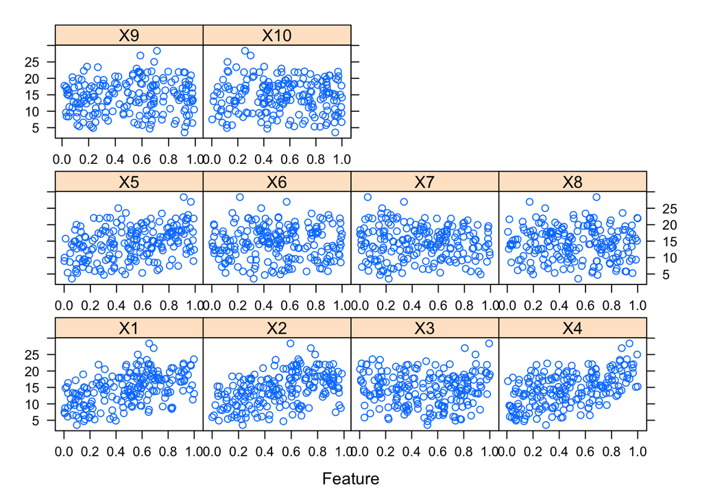

```r
set.seed(200)

trainingData <- mlbench.friedman1(200, sd = 1)

## We convert the 'x' data from a matrix to a data frame
## One reason is that this will give the columns names.
trainingData$x <- data.frame(trainingData$x)

## Look at the data using
featurePlot(trainingData$x, trainingData$y)
```

```r
## or other methods.

## This creates a list with a vector 'y' and a matrix
## of predictors 'x'. Also simulate a large test set to
## estimate the true error rate with good precision:
testData <- mlbench.friedman1(5000, sd = 1)
testData$x <- data.frame(testData$x)
```

Tune several models on these data. For example:

### KNN

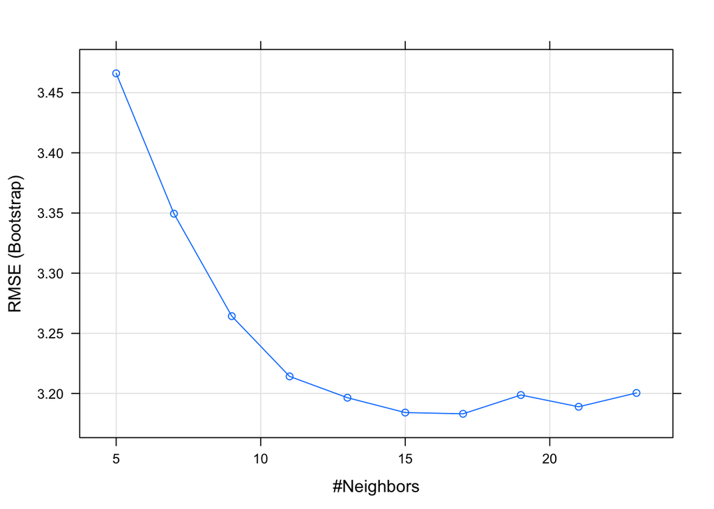

```r
cl <- makePSOCKcluster(5)
registerDoParallel(cl)

knnModel <- train(x = trainingData$x, y = trainingData$y,
  method = "knn",
  preProc = c("center", "scale"),
  tuneLength = 10)

stopCluster(cl)

# Model results
plot(knnModel)
```

```r
summary(knnModel)
```

```
##             Length Class      Mode
## learn        2     -none-     list
## k            1     -none-     numeric
## theDots      0     -none-     list
## xNames      10     -none-     character
## problemType  1     -none-     character
## tuneValue    1     data.frame list
## obsLevels    1     -none-     logical
## param        0     -none-     list
```

```r
varImp(knnModel)
```

```
## loess r-squared variable importance
##
##      Overall
## X4  100.0000
## X1   95.5047
## X2   89.6186
## X5   45.2170
## X3   29.9330
## X9    6.3299
## X10   5.5182
## X8    3.2527
## X6    0.8884
## X7    0.0000
```

```r
knnPred <- predict(knnModel, newdata = testData$x)

## The function 'postResample' can be used to get the test set
## perforamnce values
(knnPerf <- postResample(pred = knnPred, obs = testData$y))
```

```
##      RMSE  Rsquared       MAE
## 3.2040595 0.6819919 2.5683461
```

### NNET

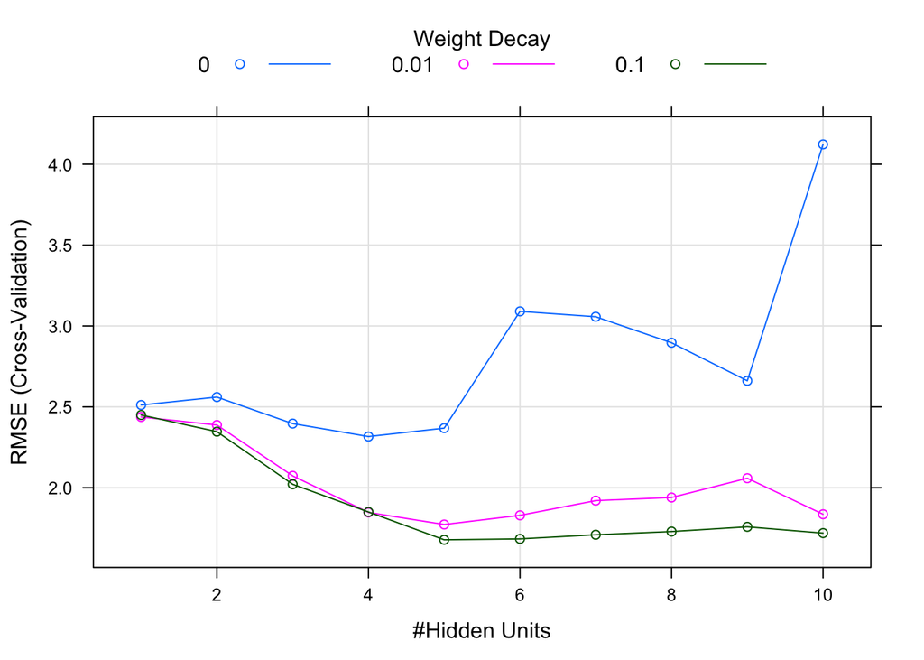

```r
cl <- makePSOCKcluster(5)
registerDoParallel(cl)

## Create a specific candidate set of models to evaluate:
nnetGrid <- expand.grid(
  .decay = c(0, 0.01, .1),
  .size = c(1:10),
  ## The next option is to use bagging (see the
  ## next chapter) instead of different random
  ## seeds.
  .bag = FALSE)

ctrl <- trainControl(method='cv', number=10)

nnetModel <- train(trainingData$x, trainingData$y,
  method = "avNNet",
  tuneGrid = nnetGrid,
  trControl = ctrl,
  linout = TRUE,
  trace = FALSE,
  MaxNWts = 10 * (ncol(trainingData$x) + 1) + 10 + 1,
  maxit = 500)

stopCluster(cl)

# Model results
plot(nnetModel)
```

```r
summary(nnetModel)
```

```
##             Length Class      Mode
## model        5     -none-     list
## repeats      1     -none-     numeric
## bag          1     -none-     logical
## seeds        5     -none-     numeric
## names       10     -none-     character
## terms        3     terms      call
## coefnames   10     -none-     character
## xlevels      0     -none-     list
## xNames      10     -none-     character
## problemType  1     -none-     character
## tuneValue    3     data.frame list
## obsLevels    1     -none-     logical
## param        4     -none-     list
```

```r
varImp(nnetModel)
```

```
## loess r-squared variable importance
##
##      Overall
## X4  100.0000
## X1   95.5047
## X2   89.6186
## X5   45.2170
## X3   29.9330
## X9    6.3299
## X10   5.5182
## X8    3.2527
## X6    0.8884
## X7    0.0000
```

```r
nnetPred <- predict(nnetModel, newdata = testData$x)

## The function 'postResample' can be used to get the test set
## perforamnce values
(nnetPerf <- postResample(pred = nnetPred, obs = testData$y))
```

```
##      RMSE  Rsquared       MAE
## 1.6644075 0.8905623 1.2423150
```

### SVM

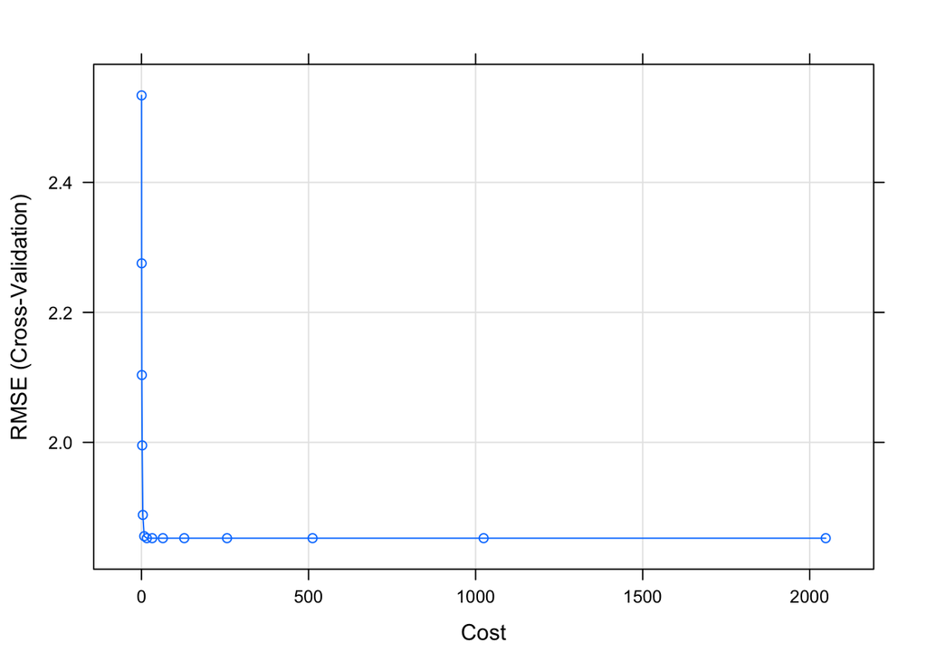

```r
cl <- makePSOCKcluster(5)
registerDoParallel(cl)

svmModel <- train(trainingData$x, trainingData$y,
  method = "svmRadial",  # svmRadial, svmLinear, svmPoly
  tuneLength = 14,
  trControl = trainControl(method = "cv"))

stopCluster(cl)

# Model results
plot(svmModel)
```

```r
summary(svmModel)
```

```
## Length  Class   Mode
##      1   ksvm     S4
```

```r
varImp(svmModel)
```

```
## loess r-squared variable importance
##
##      Overall
## X4  100.0000
## X1   95.5047
## X2   89.6186
## X5   45.2170
## X3   29.9330
## X9    6.3299
## X10   5.5182
## X8    3.2527
## X6    0.8884
## X7    0.0000
```

```r
svmPred <- predict(svmModel, newdata = testData$x)

## The function 'postResample' can be used to get the test set
## perforamnce values
(svmPerf <- postResample(pred = svmPred, obs = testData$y))
```

```
##      RMSE  Rsquared       MAE
## 2.0893300 0.8232353 1.5877434
```

### MARS

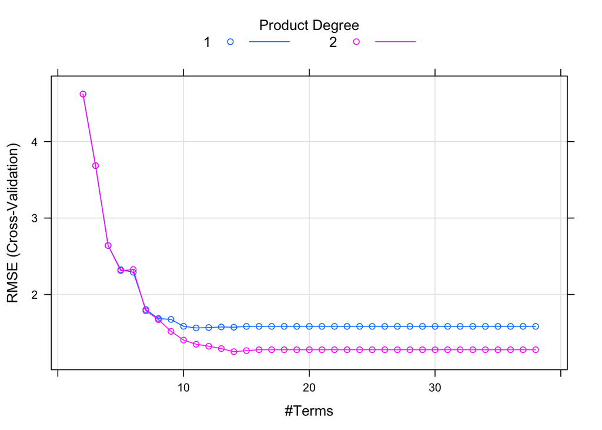

```r
cl <- makePSOCKcluster(5)
registerDoParallel(cl)

# Define the candidate models to test
marsGrid <- expand.grid(.degree = 1:2, .nprune = 2:38)

marsModel <- train(trainingData$x, trainingData$y,
  method = "earth",
  tuneGrid = marsGrid,
  trControl = trainControl(method = "cv"))

stopCluster(cl)

# Model results
plot(marsModel)
```

```r
summary(marsModel)
```

```
## Call: earth(x=data.frame[200,10], y=c(18.46,16.1,17...), keepxy=TRUE, degree=2,
##             nprune=14)
##
##                                 coefficients
## (Intercept)                        21.905319
## h(0.621722-X1)                    -15.726181
## h(X1-0.621722)                      9.234027
## h(0.601063-X2)                    -18.253527
## h(X2-0.601063)                     10.448545
## h(0.447442-X3)                      9.700589
## h(X3-0.606015)                     12.674694
## h(0.734892-X4)                     -9.863526
## h(X4-0.734892)                     10.297964
## h(0.850094-X5)                     -5.324175
## h(0.218266-X1) * h(X2-0.601063)   -55.358726
## h(X1-0.218266) * h(X2-0.601063)   -29.100250
## h(X1-0.621722) * h(X2-0.295997)   -26.833129
## h(0.649253-X1) * h(0.601063-X2)    27.120721
##
## Selected 14 of 18 terms, and 5 of 10 predictors (nprune=14)
## Termination condition: Reached nk 21
## Importance: X1, X4, X2, X5, X3, X6-unused, X7-unused, X8-unused, X9-unused, ...
## Number of terms at each degree of interaction: 1 9 4
## GCV 1.62945    RSS 225.8601    GRSq 0.9338437    RSq 0.953688
```

```r
varImp(marsModel)
```

```
## earth variable importance
##
##    Overall
## X1  100.00
## X4   75.24
## X2   48.74
## X5   15.53
## X3    0.00
```

```r
marsPred <- predict(marsModel, newdata = testData$x)

## The function 'postResample' can be used to get the test set
## perforamnce values
(marsPerf <- postResample(pred = marsPred, obs = testData$y))
```

```
##      RMSE  Rsquared       MAE
## 1.1722635 0.9448890 0.9324923
```

### Results

Which models appear to give the best performance? Does MARS select the informative predictors (those named X1–X5)?

```r
(models_summary <- rbind(nnetPerf, marsPerf, svmPerf, knnPerf))
```

```
##              RMSE  Rsquared       MAE
## nnetPerf 1.664408 0.8905623 1.2423150
## marsPerf 1.172263 0.9448890 0.9324923
## svmPerf  2.089330 0.8232353 1.5877434
## knnPerf  3.204059 0.6819919 2.5683461
```

> All three models (KNN, MARS and SVM) identified `X4`, `X1`, `X2`, `X5`, and `X3` as the top 5 features. The only difference is that MARS had `X1` as 1st and `X4` as 2nd. The others had `X4` 1st and `x1` 2nd.

## Problem 7.5

7.5. Exercise 6.3 describes data for a chemical manufacturing process. Use the same data imputation, data splitting, and pre-processing steps as before and train several nonlinear regression models.

### Load & Clean Data

```r
# NOTE: Code copied from my Homework #7
data("ChemicalManufacturingProcess")

cmp <- as_tibble(ChemicalManufacturingProcess)

x_raw <- cmp[,2:58]
y_raw <- as.matrix(cmp$Yield)

print(paste(nrow(x_raw), ncol(x_raw)))
```

```
## [1] "176 57"
```

```r
print(paste(nrow(y_raw), ncol(y_raw)))
```

```
## [1] "176 1"
```

```r
# Various NA plots to inspect data
knitr::kable(miss_var_summary(cmp) %>% filter(n_miss > 0),
             caption = 'Missing Values',
             format="html",
             table.attr="style='width:50%;'") %>%
  kableExtra::kable_styling()
```

Missing Values

| variable | n_miss | pct_miss |
| --- | --- | --- |
| ManufacturingProcess03 | 15 | 8.5227273 |
| ManufacturingProcess11 | 10 | 5.6818182 |
| ManufacturingProcess10 | 9 | 5.1136364 |
| ManufacturingProcess25 | 5 | 2.8409091 |
| ManufacturingProcess26 | 5 | 2.8409091 |
| ManufacturingProcess27 | 5 | 2.8409091 |
| ManufacturingProcess28 | 5 | 2.8409091 |
| ManufacturingProcess29 | 5 | 2.8409091 |
| ManufacturingProcess30 | 5 | 2.8409091 |
| ManufacturingProcess31 | 5 | 2.8409091 |
| ManufacturingProcess33 | 5 | 2.8409091 |
| ManufacturingProcess34 | 5 | 2.8409091 |
| ManufacturingProcess35 | 5 | 2.8409091 |
| ManufacturingProcess36 | 5 | 2.8409091 |
| ManufacturingProcess02 | 3 | 1.7045455 |
| ManufacturingProcess06 | 2 | 1.1363636 |
| ManufacturingProcess01 | 1 | 0.5681818 |
| ManufacturingProcess04 | 1 | 0.5681818 |
| ManufacturingProcess05 | 1 | 0.5681818 |
| ManufacturingProcess07 | 1 | 0.5681818 |
| ManufacturingProcess08 | 1 | 0.5681818 |
| ManufacturingProcess12 | 1 | 0.5681818 |
| ManufacturingProcess14 | 1 | 0.5681818 |
| ManufacturingProcess22 | 1 | 0.5681818 |
| ManufacturingProcess23 | 1 | 0.5681818 |
| ManufacturingProcess24 | 1 | 0.5681818 |
| ManufacturingProcess40 | 1 | 0.5681818 |
| ManufacturingProcess41 | 1 | 0.5681818 |

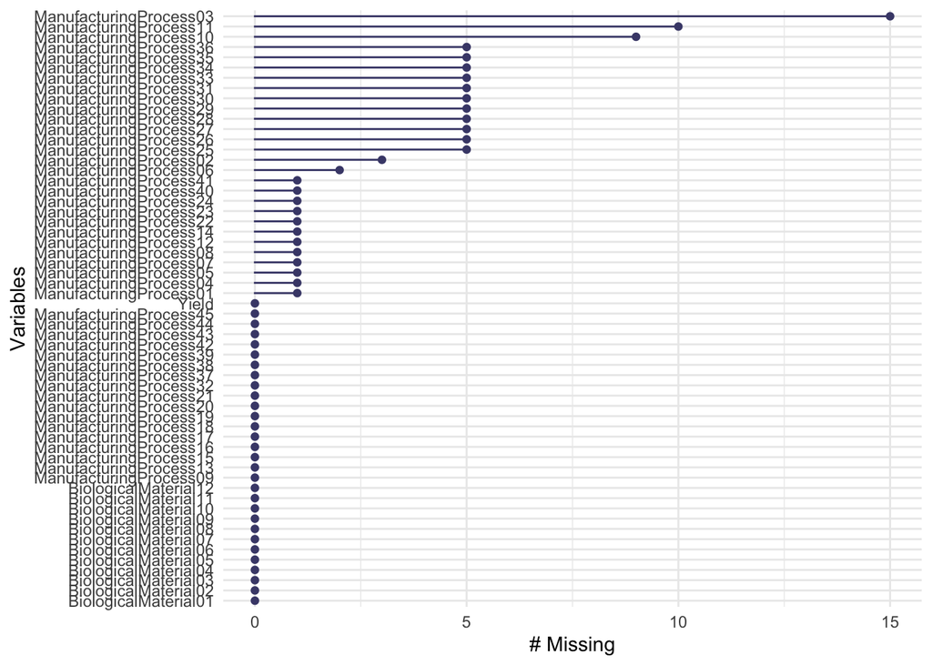

```r
gg_miss_var(cmp)
```

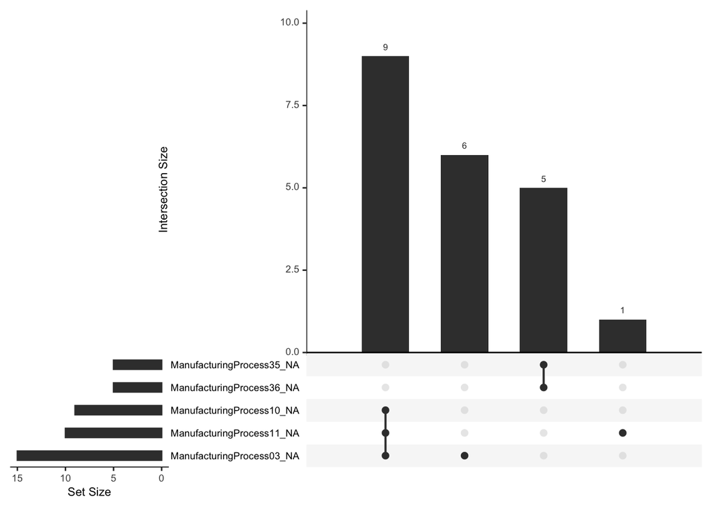

```r
gg_miss_upset(cmp)
```

```r
# Impute missing using KNN
x_imputed <- knn.impute(as.matrix(x_raw), k=10)

# Check for columns with little variance - candidate to drop
lowVariance <- nearZeroVar(x_imputed, names = TRUE)
head(lowVariance)
```

```
## [1] "BiologicalMaterial07"
```

```r
lowVariance <- nearZeroVar(x_imputed)

x_lowvar <- x_imputed[,-lowVariance]

# Deal with outliers ... impute to median
x_outliers <- outlieR::impute(x_lowvar, fill='median')

# Find and drop high correlation features
correlations <- cor(x_outliers)
highCorr <- findCorrelation(correlations, names=TRUE, cutoff=0.9)
(highCorr)
```

```
## [1] "BiologicalMaterial02"   "ManufacturingProcess26" "BiologicalMaterial04"
## [4] "BiologicalMaterial12"   "ManufacturingProcess11" "ManufacturingProcess27"
## [7] "ManufacturingProcess44" "ManufacturingProcess40"
```

```r
highCorr <- findCorrelation(correlations, cutoff=0.9)
x_corr <- x_outliers[,-highCorr]

# Transofrm our dat (scale, center, boxcox)
x_transf <-  preProcess(x_corr, method=c('center', 'scale', 'BoxCox'))
x_transf <- predict(x_transf, x_corr)
```

### Split Training/Testing:

```r
# get training/test split
trainingRows <- createDataPartition(y_raw, p=0.8, list=FALSE)

# Build training datasets
trainX <- x_transf[trainingRows,]
trainY <- y_raw[trainingRows]

# put remaining rows into the test sets
testX <- x_transf[-trainingRows,]
testY <- y_raw[-trainingRows]

# Build a DF
trainingData <- as.data.frame(trainX)
trainingData$Yield <- trainY
```

### Part (A)

1. Which nonlinear regression model gives the optimal resampling and test set performance?

#### Neural Net

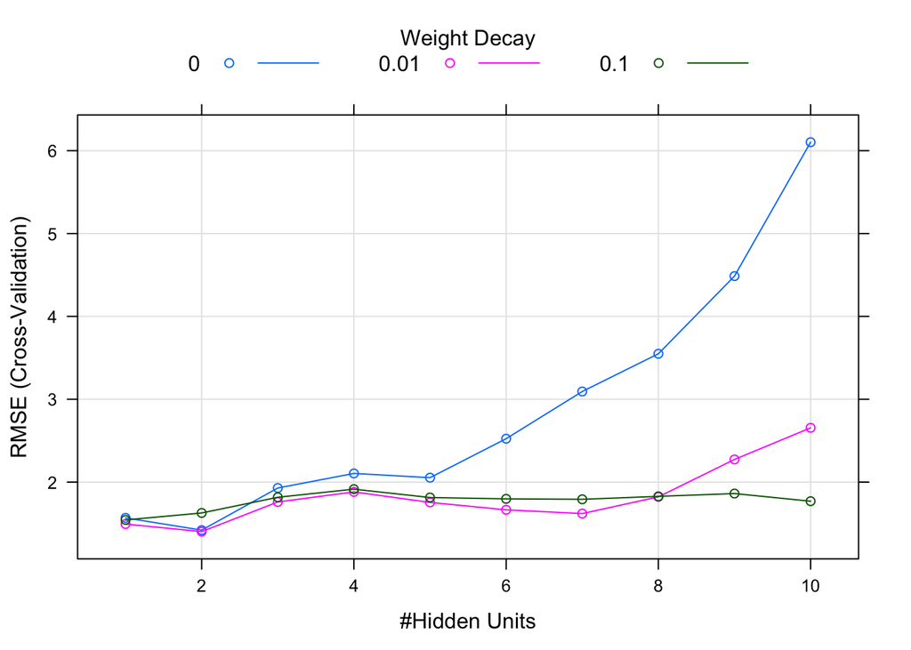

```r
set.seed(42424)

cl <- makePSOCKcluster(5)
registerDoParallel(cl)

## Create a specific candidate set of models to evaluate:
nnetGrid <- expand.grid(
  .decay = c(0, 0.01, .1),
  .size = c(1:10),
  ## The next option is to use bagging (see the
  ## next chapter) instead of different random
  ## seeds.
  .bag = FALSE)

ctrl <- trainControl(method='cv', number=10)

nnetTune <- train(trainX, trainY,
  method = "avNNet",
  tuneGrid = nnetGrid,
  trControl = ctrl,
  linout = TRUE,
  trace = FALSE,
  MaxNWts = 10 * (ncol(trainX) + 1) + 10 + 1,
  maxit = 500)

stopCluster(cl)

# Model results
plot(nnetTune)
```

```r
summary(nnetTune)
```

```
##             Length Class      Mode
## model        5     -none-     list
## repeats      1     -none-     numeric
## bag          1     -none-     logical
## seeds        5     -none-     numeric
## names       48     -none-     character
## terms        3     terms      call
## coefnames   48     -none-     character
## xlevels      0     -none-     list
## xNames      48     -none-     character
## problemType  1     -none-     character
## tuneValue    3     data.frame list
## obsLevels    1     -none-     logical
## param        4     -none-     list
```

```r
varImp(nnetTune)
```

```
## loess r-squared variable importance
##
##   only 20 most important variables shown (out of 48)
##
##                        Overall
## ManufacturingProcess32  100.00
## BiologicalMaterial06     89.09
## ManufacturingProcess13   79.04
## BiologicalMaterial03     77.63
## ManufacturingProcess09   75.31
## ManufacturingProcess31   74.87
## ManufacturingProcess36   72.14
## ManufacturingProcess17   69.93
## ManufacturingProcess06   62.10
## ManufacturingProcess30   55.24
## ManufacturingProcess33   53.74
## BiologicalMaterial11     46.95
## BiologicalMaterial01     40.10
## ManufacturingProcess18   38.18
## BiologicalMaterial09     36.04
## ManufacturingProcess25   35.93
## BiologicalMaterial08     35.81
## ManufacturingProcess20   34.31
## ManufacturingProcess29   34.04
## ManufacturingProcess15   33.15
```

```r
modelPred <- predict(nnetTune, newdata=testX)

modelValues <- data.frame(obs = testY, pred=modelPred)
colnames(modelValues) = c('obs', 'pred')
(nnet_values <- defaultSummary(modelValues))
```

```
##      RMSE  Rsquared       MAE
## 1.2146853 0.6426541 0.8962163
```

#### MARS

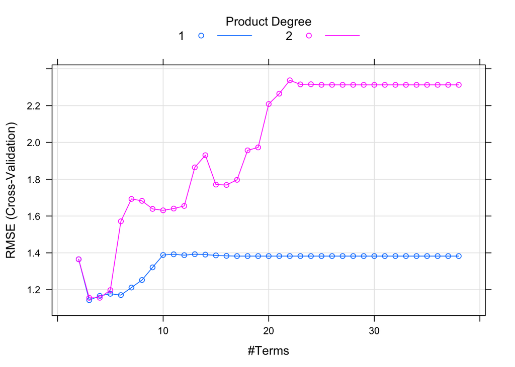

```r
set.seed(42424)

# Define the candidate models to test
marsGrid <- expand.grid(.degree = 1:2, .nprune = 2:38)

cl <- makePSOCKcluster(5)
registerDoParallel(cl)

marsTune <- train(trainX, trainY,
  method = "earth",
  tuneGrid = marsGrid,
  trControl = trainControl(method = "cv"))

stopCluster(cl)

# Model Results
plot(marsTune)
```

```r
summary(marsTune)
```

```
## Call: earth(x=matrix[144,48], y=c(42.44,42.03,4...), keepxy=TRUE, degree=1,
##             nprune=3)
##
##                                      coefficients
## (Intercept)                             39.647909
## h(0.553668-ManufacturingProcess09)      -1.037195
## h(ManufacturingProcess32- -0.813021)     1.323398
##
## Selected 3 of 21 terms, and 2 of 48 predictors (nprune=3)
## Termination condition: RSq changed by less than 0.001 at 21 terms
## Importance: ManufacturingProcess32, ManufacturingProcess09, ...
## Number of terms at each degree of interaction: 1 2 (additive model)
## GCV 1.369288    RSS 183.7224    GRSq 0.5808792    RSq 0.6039985
```

```r
varImp(marsTune)
```

```
## earth variable importance
##
##                        Overall
## ManufacturingProcess32     100
## ManufacturingProcess09       0
```

```r
modelPred <- predict(marsTune, newdata=testX)

modelValues <- data.frame(obs = testY, pred=modelPred)
colnames(modelValues) = c('obs', 'pred')
(mars_values <- defaultSummary(modelValues))
```

```
##      RMSE  Rsquared       MAE
## 1.3016929 0.5974956 1.0242889
```

#### SVM

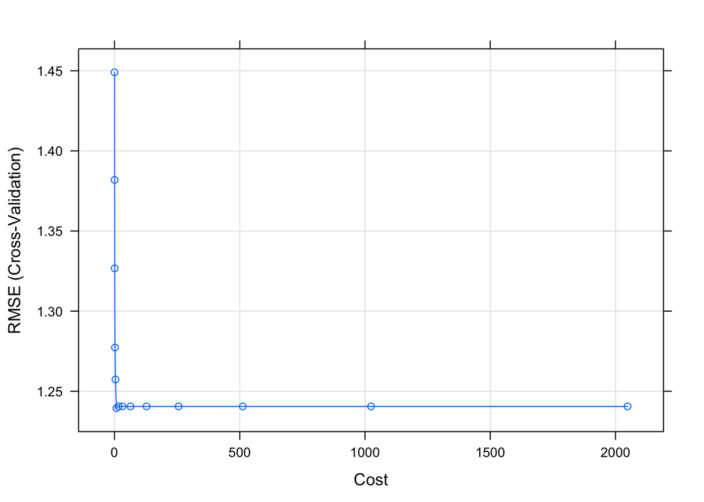

```r
set.seed(42424)

cl <- makePSOCKcluster(5)
registerDoParallel(cl)

svmRTune <- train(trainX, trainY,
  method = "svmRadial",  # svmRadial, svmLinear, svmPoly
  tuneLength = 14,
  trControl = trainControl(method = "cv"))

stopCluster(cl)

# Model Results
plot(svmRTune)
```

```r
summary(svmRTune)
```

```
## Length  Class   Mode
##      1   ksvm     S4
```

```r
varImp(svmRTune)
```

```
## loess r-squared variable importance
##
##   only 20 most important variables shown (out of 48)
##
##                        Overall
## ManufacturingProcess32  100.00
## BiologicalMaterial06     89.09
## ManufacturingProcess13   79.04
## BiologicalMaterial03     77.63
## ManufacturingProcess09   75.31
## ManufacturingProcess31   74.87
## ManufacturingProcess36   72.14
## ManufacturingProcess17   69.93
## ManufacturingProcess06   62.10
## ManufacturingProcess30   55.24
## ManufacturingProcess33   53.74
## BiologicalMaterial11     46.95
## BiologicalMaterial01     40.10
## ManufacturingProcess18   38.18
## BiologicalMaterial09     36.04
## ManufacturingProcess25   35.93
## BiologicalMaterial08     35.81
## ManufacturingProcess20   34.31
## ManufacturingProcess29   34.04
## ManufacturingProcess15   33.15
```

```r
modelPred <- predict(svmRTune, newdata=testX)

modelValues <- data.frame(obs = testY, pred=modelPred)
colnames(modelValues) = c('obs', 'pred')
(svm_values <- defaultSummary(modelValues))
```

```
##     RMSE Rsquared      MAE
## 1.146482 0.713360 0.859768
```

#### KNN

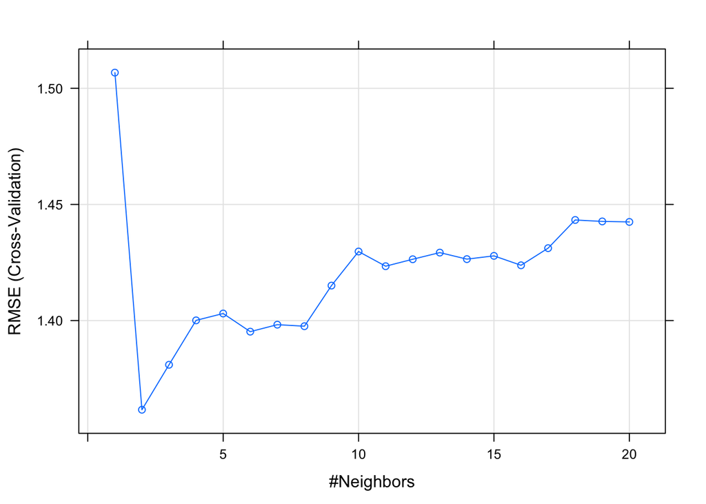

```r
set.seed(42424)

cl <- makePSOCKcluster(5)
registerDoParallel(cl)

knnTune <- train(trainX, trainY,
  method = "knn",
  # Center and scaling will occur for new predictions too
  preProc = c("center", "scale"),
  tuneGrid = data.frame(.k = 1:20),
  trControl = trainControl(method = "cv"))

stopCluster(cl)

# Model Results
plot(knnTune)
```

```r
summary(knnTune)
```

```
##             Length Class      Mode
## learn        2     -none-     list
## k            1     -none-     numeric
## theDots      0     -none-     list
## xNames      48     -none-     character
## problemType  1     -none-     character
## tuneValue    1     data.frame list
## obsLevels    1     -none-     logical
## param        0     -none-     list
```

```r
varImp(knnTune)
```

```
## loess r-squared variable importance
##
##   only 20 most important variables shown (out of 48)
##
##                        Overall
## ManufacturingProcess32  100.00
## BiologicalMaterial06     89.09
## ManufacturingProcess13   79.04
## BiologicalMaterial03     77.63
## ManufacturingProcess09   75.31
## ManufacturingProcess31   74.87
## ManufacturingProcess36   72.14
## ManufacturingProcess17   69.93
## ManufacturingProcess06   62.10
## ManufacturingProcess30   55.24
## ManufacturingProcess33   53.74
## BiologicalMaterial11     46.95
## BiologicalMaterial01     40.10
## ManufacturingProcess18   38.18
## BiologicalMaterial09     36.04
## ManufacturingProcess25   35.93
## BiologicalMaterial08     35.81
## ManufacturingProcess20   34.31
## ManufacturingProcess29   34.04
## ManufacturingProcess15   33.15
```

```r
modelPred <- predict(knnTune, newdata=testX)

modelValues <- data.frame(obs = testY, pred=modelPred)
colnames(modelValues) = c('obs', 'pred')
(knn_values <- defaultSummary(modelValues))
```

```
##      RMSE  Rsquared       MAE
## 1.4621971 0.4875616 1.0596875
```

#### Models Summary

```r
(models_summary <- rbind(nnet_values, mars_values, svm_values, knn_values))
```

```
##                 RMSE  Rsquared       MAE
## nnet_values 1.214685 0.6426541 0.8962163
## mars_values 1.301693 0.5974956 1.0242889
## svm_values  1.146482 0.7133600 0.8597680
## knn_values  1.462197 0.4875616 1.0596875
```

> Referring back to Problem 6.3 in Homwwork #7, these same 4 features also show as top using `varImp()`. However, we improved our RMSE and Rsquared values using non-linear models over the linear counterparts.
3. Explore the relationships between the top predictors and the response for the predictors that are unique to the optimal nonlinear regression model. Do these plots reveal intuition about the biological or process predictors and their relationship with yield?

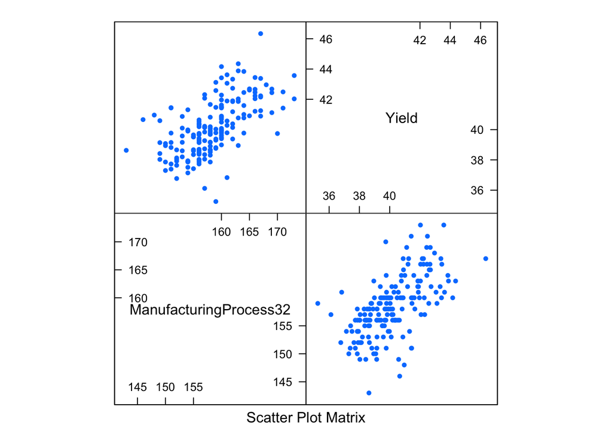

```r
df <- cmp %>%
  dplyr::select(c('ManufacturingProcess32', 'ManufacturingProcess13', 'ManufacturingProcess09', 'BiologicalMaterial06', 'Yield'))


caret::featurePlot(x=df['ManufacturingProcess32'], y=df['Yield'], plot="pairs", pch=20)
```

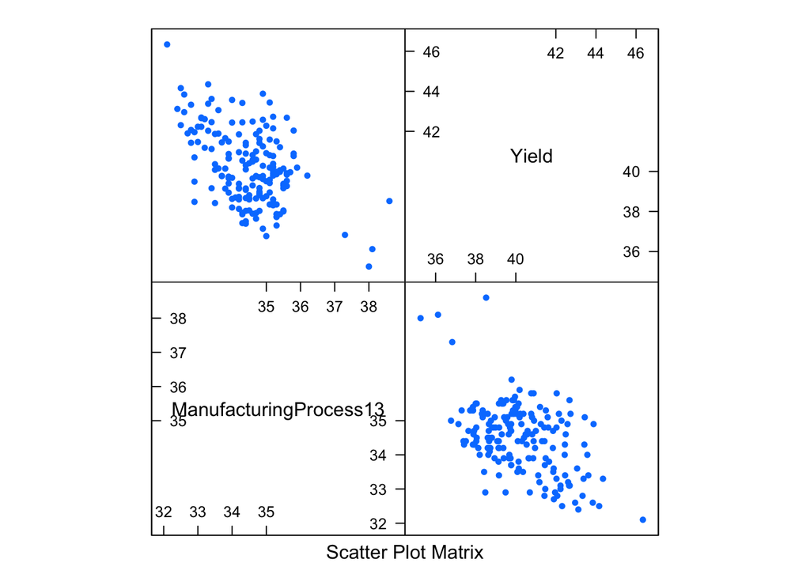

```r
caret::featurePlot(x=df['ManufacturingProcess13'], y=df['Yield'], plot="pairs", pch=20)
```

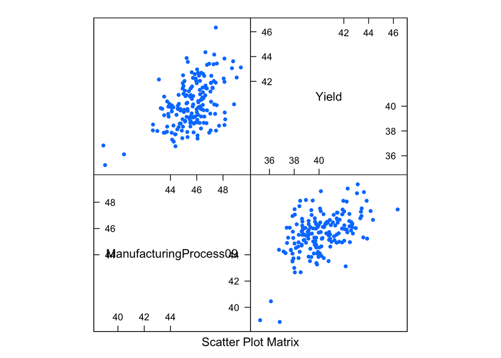

```r
caret::featurePlot(x=df['ManufacturingProcess09'], y=df['Yield'], plot="pairs", pch=20)
```

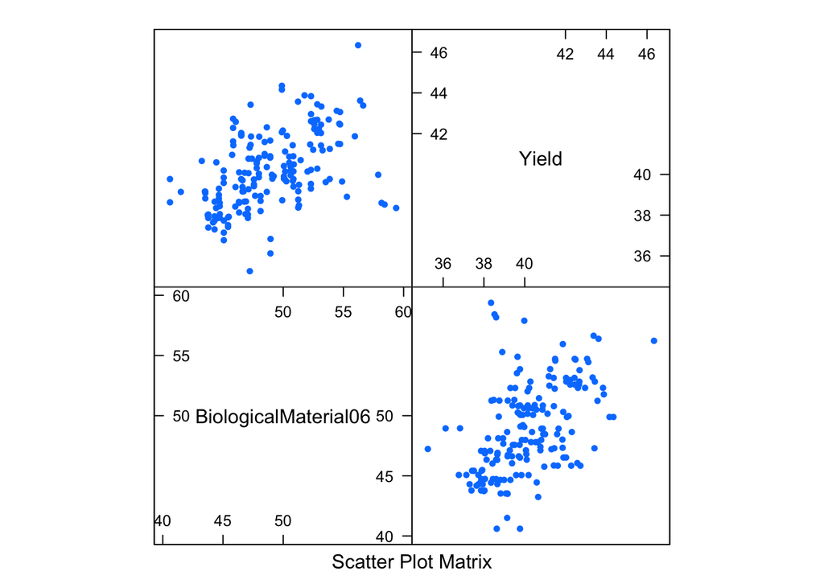

```r
caret::featurePlot(x=df['BiologicalMaterial06'], y=df['Yield'], plot="pairs", pch=20)
```

SInce we don’t actually know what each Process physically maps to in the real world, it’s a little hard to apply intuition. I don’t know how `ManufacturingProcess32` differs from `ManufacturingProcess09`. That said, we do see clear patterns between the features and `Yield` which we would expect since these were shown to be the top predictors. Had we seen no visual relationships, it’s possible there was still one detectable in the math, but that would have been concerning. `ManufacturingProcess32`, `ManufacturingProcess09`, and `BiologicalMaterial06` show increase in `Yield` with an increase in the feature. `ManufacturingProcess13` shows a decrease in `Yield` as the feature increases.